# Optimal Treatment Analysis

## Outcome Variable

**Outcome Variable:** haz

## Predictor Variables

**Intervention Variable:** gagebrth

**Adjustment Set:**

- arm
- sex
- W_mage
- meducyrs
- feducyrs
- hhwealth_quart
- W_nrooms
- W_nchldlt5
- brthmon
- W_parity
- impsan
- delta_W_mage
- delta_meducyrs
- delta_feducyrs
- delta_hhwealth_quart
- delta_W_nrooms
- delta_W_nchldlt5
- delta_brthmon
- delta_W_parity
- delta_impsan

## Stratifying Variables

The analysis was stratified on these variable(s):

- agecat
- studyid
- country

## Data Summary

| agecat | studyid | country | gagebrth | n_cell | n |
| --- | --- | --- | --- | --- | --- |
| Birth | ki1000108-CMC-V-BCS-2002 | INDIA | Full or late term | 58 | 92 |
| Birth | ki1000108-CMC-V-BCS-2002 | INDIA | Preterm | 11 | 92 |
| Birth | ki1000108-CMC-V-BCS-2002 | INDIA | Early term | 23 | 92 |
| Birth | ki1000108-IRC | INDIA | Full or late term | 238 | 369 |
| Birth | ki1000108-IRC | INDIA | Preterm | 36 | 369 |
| Birth | ki1000108-IRC | INDIA | Early term | 95 | 369 |
| Birth | ki1000109-EE | PAKISTAN | Full or late term | 11 | 240 |
| Birth | ki1000109-EE | PAKISTAN | Preterm | 182 | 240 |
| Birth | ki1000109-EE | PAKISTAN | Early term | 47 | 240 |
| Birth | ki1017093c-NIH-Crypto | BANGLADESH | Full or late term | 162 | 732 |
| Birth | ki1017093c-NIH-Crypto | BANGLADESH | Preterm | 257 | 732 |
| Birth | ki1017093c-NIH-Crypto | BANGLADESH | Early term | 313 | 732 |
| Birth | ki1101329-Keneba | GAMBIA | Full or late term | 734 | 1515 |
| Birth | ki1101329-Keneba | GAMBIA | Preterm | 235 | 1515 |
| Birth | ki1101329-Keneba | GAMBIA | Early term | 546 | 1515 |
| Birth | ki1119695-PROBIT | BELARUS | Full or late term | 7098 | 13890 |
| Birth | ki1119695-PROBIT | BELARUS | Preterm | 472 | 13890 |
| Birth | ki1119695-PROBIT | BELARUS | Early term | 6320 | 13890 |
| Birth | ki1135781-COHORTS | GUATEMALA | Full or late term | 341 | 617 |
| Birth | ki1135781-COHORTS | GUATEMALA | Preterm | 95 | 617 |
| Birth | ki1135781-COHORTS | GUATEMALA | Early term | 181 | 617 |
| Birth | ki1135781-COHORTS | INDIA | Full or late term | 570 | 1293 |
| Birth | ki1135781-COHORTS | INDIA | Preterm | 285 | 1293 |
| Birth | ki1135781-COHORTS | INDIA | Early term | 438 | 1293 |
| Birth | ki1135781-COHORTS | PHILIPPINES | Full or late term | 1164 | 3024 |
| Birth | ki1135781-COHORTS | PHILIPPINES | Preterm | 649 | 3024 |
| Birth | ki1135781-COHORTS | PHILIPPINES | Early term | 1211 | 3024 |
| Birth | kiGH5241-JiVitA-3 | BANGLADESH | Full or late term | 13089 | 25394 |
| Birth | kiGH5241-JiVitA-3 | BANGLADESH | Preterm | 5265 | 25394 |
| Birth | kiGH5241-JiVitA-3 | BANGLADESH | Early term | 7040 | 25394 |

[output cut: 66 more lines]

The following strata were considered:

- agecat: 24 months, studyid: ki1000108-CMC-V-BCS-2002, country: INDIA
- agecat: 24 months, studyid: ki1000108-IRC, country: INDIA
- agecat: 24 months, studyid: ki1000109-EE, country: PAKISTAN
- agecat: 24 months, studyid: ki1017093c-NIH-Crypto, country: BANGLADESH
- agecat: 24 months, studyid: ki1066203-TanzaniaChild2, country: TANZANIA, UNITED REPUBLIC OF
- agecat: 24 months, studyid: ki1101329-Keneba, country: GAMBIA
- agecat: 24 months, studyid: ki1119695-PROBIT, country: BELARUS
- agecat: 24 months, studyid: ki1135781-COHORTS, country: GUATEMALA
- agecat: 24 months, studyid: ki1135781-COHORTS, country: INDIA
- agecat: 24 months, studyid: ki1135781-COHORTS, country: PHILIPPINES
- agecat: 24 months, studyid: kiGH5241-JiVitA-3, country: BANGLADESH
- agecat: 6 months, studyid: ki1000108-CMC-V-BCS-2002, country: INDIA
- agecat: 6 months, studyid: ki1000108-IRC, country: INDIA
- agecat: 6 months, studyid: ki1000109-EE, country: PAKISTAN
- agecat: 6 months, studyid: ki1017093c-NIH-Crypto, country: BANGLADESH
- agecat: 6 months, studyid: ki1066203-TanzaniaChild2, country: TANZANIA, UNITED REPUBLIC OF
- agecat: 6 months, studyid: ki1101329-Keneba, country: GAMBIA
- agecat: 6 months, studyid: ki1119695-PROBIT, country: BELARUS
- agecat: 6 months, studyid: ki1135781-COHORTS, country: GUATEMALA
- agecat: 6 months, studyid: ki1135781-COHORTS, country: INDIA
- agecat: 6 months, studyid: ki1135781-COHORTS, country: PHILIPPINES
- agecat: 6 months, studyid: kiGH5241-JiVitA-3, country: BANGLADESH
- agecat: Birth, studyid: ki1000108-CMC-V-BCS-2002, country: INDIA
- agecat: Birth, studyid: ki1000108-IRC, country: INDIA
- agecat: Birth, studyid: ki1000109-EE, country: PAKISTAN
- agecat: Birth, studyid: ki1017093c-NIH-Crypto, country: BANGLADESH
- agecat: Birth, studyid: ki1101329-Keneba, country: GAMBIA
- agecat: Birth, studyid: ki1119695-PROBIT, country: BELARUS
- agecat: Birth, studyid: ki1135781-COHORTS, country: GUATEMALA
- agecat: Birth, studyid: ki1135781-COHORTS, country: INDIA
- agecat: Birth, studyid: ki1135781-COHORTS, country: PHILIPPINES
- agecat: Birth, studyid: kiGH5241-JiVitA-3, country: BANGLADESH

### Dropped Strata

Some strata were dropped due to rare outcomes:

- agecat: 24 months, studyid: ki1066203-TanzaniaChild2, country: TANZANIA, UNITED REPUBLIC OF

## Methods Detail

We’re interested in the causal parameters $E[Y_a]$ for all values of $a \in \mathcal{A}$. These parameters represent the mean outcome if, possibly contrary to fact, we intervened to set all units to have $A=a$. Under the randomization and positivity assumptions, these are identified by the statistical parameters $\psi_a=E_W[E_{Y|A,W}(Y|A=a,W)]$. In addition, we’re interested in the mean of $Y$, $E[Y]$ under no intervention (the observed mean). We will estimate these parameters by using SuperLearner to fit the relevant likelihood factors – $E_{Y|A,W}(Y|A=a,W)$ and $p(A=a|W)$, and then updating our likelihood fit using a joint TMLE.

For unadjusted analyses ($W=\{\}$), initial likelihoods were estimated using Lrnr_glm to estimate the simple $E(Y|A)$ and Lrnr_mean to estimate $p(A)$. For adjusted analyses, a small library containing Lrnr_glmnet, Lrnr_xgboost, and Lrnr_mean was used.

Having estimated these parameters, we will then use the delta method to estimate relative risks and attributable risks relative to a prespecified baseline level of $A$.

# Results Detail

## Results Plots

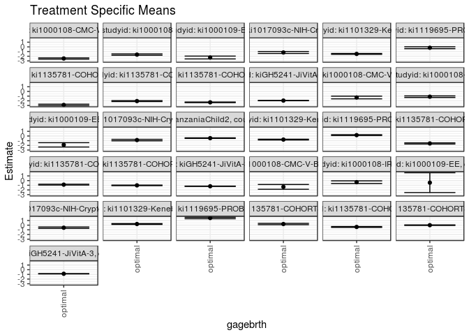

## Results Table

### Parameter: TSM

| agecat | studyid | country | intervention_level | baseline_level | estimate | ci_lower | ci_upper |
| --- | --- | --- | --- | --- | --- | --- | --- |
| Birth | ki1000108-CMC-V-BCS-2002 | INDIA | optimal | observed | -1.3459432 | -1.8556235 | -0.8362628 |
| Birth | ki1000108-IRC | INDIA | optimal | observed | -0.3427618 | -0.6263829 | -0.0591406 |
| Birth | ki1000109-EE | PAKISTAN | optimal | observed | -0.4447674 | -2.5637013 | 1.6741666 |
| Birth | ki1017093c-NIH-Crypto | BANGLADESH | optimal | observed | -0.5501485 | -0.7022044 | -0.3980925 |
| Birth | ki1101329-Keneba | GAMBIA | optimal | observed | 0.2394244 | 0.1518181 | 0.3270306 |
| Birth | ki1119695-PROBIT | BELARUS | optimal | observed | 1.5242065 | 1.3690380 | 1.6793749 |
| Birth | ki1135781-COHORTS | GUATEMALA | optimal | observed | 0.2382290 | 0.0937900 | 0.3826680 |
| Birth | ki1135781-COHORTS | INDIA | optimal | observed | -0.3884607 | -0.4779051 | -0.2990164 |
| Birth | ki1135781-COHORTS | PHILIPPINES | optimal | observed | -0.0072208 | -0.0653789 | 0.0509372 |
| Birth | kiGH5241-JiVitA-3 | BANGLADESH | optimal | observed | -0.8687946 | -0.9013321 | -0.8362571 |
| 6 months | ki1000108-CMC-V-BCS-2002 | INDIA | optimal | observed | -1.2929198 | -1.5826729 | -1.0031667 |
| 6 months | ki1000108-IRC | INDIA | optimal | observed | -1.1227667 | -1.2914956 | -0.9540377 |
| 6 months | ki1000109-EE | PAKISTAN | optimal | observed | -1.8878023 | -2.3511247 | -1.4244798 |
| 6 months | ki1017093c-NIH-Crypto | BANGLADESH | optimal | observed | -0.8658543 | -1.0222901 | -0.7094185 |
| 6 months | ki1066203-TanzaniaChild2 | TANZANIA, UNITED REPUBLIC OF | optimal | observed | -0.4599230 | -0.5241049 | -0.3957411 |
| 6 months | ki1101329-Keneba | GAMBIA | optimal | observed | -0.7655438 | -0.8490513 | -0.6820363 |
| 6 months | ki1119695-PROBIT | BELARUS | optimal | observed | 0.1856031 | 0.0918498 | 0.2793564 |
| 6 months | ki1135781-COHORTS | GUATEMALA | optimal | observed | -1.5899413 | -1.7089154 | -1.4709673 |
| 6 months | ki1135781-COHORTS | INDIA | optimal | observed | -0.8716784 | -0.9622308 | -0.7811260 |
| 6 months | ki1135781-COHORTS | PHILIPPINES | optimal | observed | -1.0242156 | -1.0907101 | -0.9577210 |
| 6 months | kiGH5241-JiVitA-3 | BANGLADESH | optimal | observed | -1.2125039 | -1.2401811 | -1.1848267 |
| 24 months | ki1000108-CMC-V-BCS-2002 | INDIA | optimal | observed | -2.4822676 | -2.6161368 | -2.3483984 |
| 24 months | ki1000108-IRC | INDIA | optimal | observed | -1.6546280 | -1.8049769 | -1.5042791 |
| 24 months | ki1000109-EE | PAKISTAN | optimal | observed | -2.2766313 | -2.5799206 | -1.9733421 |
| 24 months | ki1017093c-NIH-Crypto | BANGLADESH | optimal | observed | -1.1957994 | -1.4061865 | -0.9854123 |
| 24 months | ki1101329-Keneba | GAMBIA | optimal | observed | -1.5057597 | -1.6025059 | -1.4090134 |
| 24 months | ki1119695-PROBIT | BELARUS | optimal | observed | -0.1874485 | -0.3859289 | 0.0110320 |
| 24 months | ki1135781-COHORTS | GUATEMALA | optimal | observed | -2.8857319 | -3.0468277 | -2.7246360 |
| 24 months | ki1135781-COHORTS | INDIA | optimal | observed | -2.0571643 | -2.1545182 | -1.9598104 |
| 24 months | ki1135781-COHORTS | PHILIPPINES | optimal | observed | -2.3302285 | -2.3997106 | -2.2607464 |
| 24 months | kiGH5241-JiVitA-3 | BANGLADESH | optimal | observed | -1.9523760 | -1.9899881 | -1.9147638 |

### Parameter: E(Y)

| agecat | studyid | country | intervention_level | baseline_level | estimate | ci_lower | ci_upper |
| --- | --- | --- | --- | --- | --- | --- | --- |
| Birth | ki1000108-CMC-V-BCS-2002 | INDIA | observed | observed | -0.9611957 | -1.1776967 | -0.7446946 |
| Birth | ki1000108-IRC | INDIA | observed | observed | -0.3102981 | -0.4751168 | -0.1454794 |
| Birth | ki1000109-EE | PAKISTAN | observed | observed | -1.8608750 | -2.0482045 | -1.6735455 |
| Birth | ki1017093c-NIH-Crypto | BANGLADESH | observed | observed | -0.9094945 | -0.9809370 | -0.8380521 |
| Birth | ki1101329-Keneba | GAMBIA | observed | observed | 0.0278680 | -0.0365315 | 0.0922674 |
| Birth | ki1119695-PROBIT | BELARUS | observed | observed | 1.3269446 | 1.1683850 | 1.4855041 |
| Birth | ki1135781-COHORTS | GUATEMALA | observed | observed | 0.0530794 | -0.0441925 | 0.1503513 |
| Birth | ki1135781-COHORTS | INDIA | observed | observed | -0.6072158 | -0.6675691 | -0.5468624 |
| Birth | ki1135781-COHORTS | PHILIPPINES | observed | observed | -0.2492460 | -0.2884729 | -0.2100192 |
| Birth | kiGH5241-JiVitA-3 | BANGLADESH | observed | observed | -1.1878459 | -1.2167939 | -1.1588980 |
| 6 months | ki1000108-CMC-V-BCS-2002 | INDIA | observed | observed | -1.3856004 | -1.5319935 | -1.2392073 |
| 6 months | ki1000108-IRC | INDIA | observed | observed | -1.2321263 | -1.3660720 | -1.0981806 |
| 6 months | ki1000109-EE | PAKISTAN | observed | observed | -2.0835567 | -2.2027557 | -1.9643578 |
| 6 months | ki1017093c-NIH-Crypto | BANGLADESH | observed | observed | -1.1986783 | -1.2700937 | -1.1272630 |
| 6 months | ki1066203-TanzaniaChild2 | TANZANIA, UNITED REPUBLIC OF | observed | observed | -0.5419570 | -0.5926042 | -0.4913098 |
| 6 months | ki1101329-Keneba | GAMBIA | observed | observed | -0.8948084 | -0.9510697 | -0.8385471 |
| 6 months | ki1119695-PROBIT | BELARUS | observed | observed | 0.1069986 | 0.0122286 | 0.2017686 |
| 6 months | ki1135781-COHORTS | GUATEMALA | observed | observed | -1.8315428 | -1.9081267 | -1.7549589 |
| 6 months | ki1135781-COHORTS | INDIA | observed | observed | -0.9630335 | -1.0220763 | -0.9039908 |
| 6 months | ki1135781-COHORTS | PHILIPPINES | observed | observed | -1.1409862 | -1.1830414 | -1.0989310 |
| 6 months | kiGH5241-JiVitA-3 | BANGLADESH | observed | observed | -1.3392722 | -1.3625791 | -1.3159653 |
| 24 months | ki1000108-CMC-V-BCS-2002 | INDIA | observed | observed | -2.5319389 | -2.6335015 | -2.4303762 |
| 24 months | ki1000108-IRC | INDIA | observed | observed | -1.7964915 | -1.8912047 | -1.7017782 |
| 24 months | ki1000109-EE | PAKISTAN | observed | observed | -2.6699900 | -2.8138051 | -2.5261749 |
| 24 months | ki1017093c-NIH-Crypto | BANGLADESH | observed | observed | -1.4412646 | -1.5249156 | -1.3576135 |
| 24 months | ki1101329-Keneba | GAMBIA | observed | observed | -1.5800865 | -1.6398819 | -1.5202911 |
| 24 months | ki1119695-PROBIT | BELARUS | observed | observed | -0.1314048 | -0.4282725 | 0.1654630 |
| 24 months | ki1135781-COHORTS | GUATEMALA | observed | observed | -2.9911195 | -3.0733804 | -2.9088586 |
| 24 months | ki1135781-COHORTS | INDIA | observed | observed | -2.1289450 | -2.1901830 | -2.0677069 |
| 24 months | ki1135781-COHORTS | PHILIPPINES | observed | observed | -2.4144884 | -2.4596605 | -2.3693164 |
| 24 months | kiGH5241-JiVitA-3 | BANGLADESH | observed | observed | -2.0218641 | -2.0501149 | -1.9936133 |

### Parameter: PAR

| agecat | studyid | country | intervention_level | baseline_level | estimate | ci_lower | ci_upper |
| --- | --- | --- | --- | --- | --- | --- | --- |
| Birth | ki1000108-CMC-V-BCS-2002 | INDIA | optimal | observed | 0.3847475 | -0.0915699 | 0.8610650 |
| Birth | ki1000108-IRC | INDIA | optimal | observed | 0.0324637 | -0.2181393 | 0.2830667 |
| Birth | ki1000109-EE | PAKISTAN | optimal | observed | -1.4161076 | -3.4829392 | 0.6507240 |
| Birth | ki1017093c-NIH-Crypto | BANGLADESH | optimal | observed | -0.3593461 | -0.4955473 | -0.2231448 |
| Birth | ki1101329-Keneba | GAMBIA | optimal | observed | -0.2115564 | -0.2794058 | -0.1437069 |
| Birth | ki1119695-PROBIT | BELARUS | optimal | observed | -0.1972619 | -0.2528584 | -0.1416654 |
| Birth | ki1135781-COHORTS | GUATEMALA | optimal | observed | -0.1851496 | -0.2937858 | -0.0765133 |
| Birth | ki1135781-COHORTS | INDIA | optimal | observed | -0.2187550 | -0.2877388 | -0.1497713 |
| Birth | ki1135781-COHORTS | PHILIPPINES | optimal | observed | -0.2420252 | -0.2898645 | -0.1941859 |
| Birth | kiGH5241-JiVitA-3 | BANGLADESH | optimal | observed | -0.3190513 | -0.3406733 | -0.2974293 |
| 6 months | ki1000108-CMC-V-BCS-2002 | INDIA | optimal | observed | -0.0926806 | -0.3457604 | 0.1603993 |
| 6 months | ki1000108-IRC | INDIA | optimal | observed | -0.1093596 | -0.2082500 | -0.0104693 |
| 6 months | ki1000109-EE | PAKISTAN | optimal | observed | -0.1957545 | -0.6541270 | 0.2626181 |
| 6 months | ki1017093c-NIH-Crypto | BANGLADESH | optimal | observed | -0.3328240 | -0.4705273 | -0.1951207 |
| 6 months | ki1066203-TanzaniaChild2 | TANZANIA, UNITED REPUBLIC OF | optimal | observed | -0.0820340 | -0.1220916 | -0.0419764 |
| 6 months | ki1101329-Keneba | GAMBIA | optimal | observed | -0.1292646 | -0.1911804 | -0.0673488 |
| 6 months | ki1119695-PROBIT | BELARUS | optimal | observed | -0.0786045 | -0.1103596 | -0.0468494 |
| 6 months | ki1135781-COHORTS | GUATEMALA | optimal | observed | -0.2416015 | -0.3425433 | -0.1406596 |
| 6 months | ki1135781-COHORTS | INDIA | optimal | observed | -0.0913551 | -0.1584778 | -0.0242325 |
| 6 months | ki1135781-COHORTS | PHILIPPINES | optimal | observed | -0.1167707 | -0.1697878 | -0.0637535 |
| 6 months | kiGH5241-JiVitA-3 | BANGLADESH | optimal | observed | -0.1267683 | -0.1436537 | -0.1098830 |
| 24 months | ki1000108-CMC-V-BCS-2002 | INDIA | optimal | observed | -0.0496712 | -0.1310622 | 0.0317197 |
| 24 months | ki1000108-IRC | INDIA | optimal | observed | -0.1418635 | -0.2579354 | -0.0257915 |
| 24 months | ki1000109-EE | PAKISTAN | optimal | observed | -0.3933587 | -0.6806488 | -0.1060686 |
| 24 months | ki1017093c-NIH-Crypto | BANGLADESH | optimal | observed | -0.2454652 | -0.4398534 | -0.0510771 |
| 24 months | ki1101329-Keneba | GAMBIA | optimal | observed | -0.0743268 | -0.1516324 | 0.0029787 |
| 24 months | ki1119695-PROBIT | BELARUS | optimal | observed | 0.0560437 | -0.1665723 | 0.2786597 |
| 24 months | ki1135781-COHORTS | GUATEMALA | optimal | observed | -0.1053876 | -0.2436350 | 0.0328597 |
| 24 months | ki1135781-COHORTS | INDIA | optimal | observed | -0.0717806 | -0.1456717 | 0.0021104 |
| 24 months | ki1135781-COHORTS | PHILIPPINES | optimal | observed | -0.0842599 | -0.1402574 | -0.0282625 |
| 24 months | kiGH5241-JiVitA-3 | BANGLADESH | optimal | observed | -0.0694881 | -0.0920308 | -0.0469455 |